# Week 10 Revision exercise

2026-07-15

# (a)

```r
# Calling my packages
library("tidyverse")
```

```r
library("ggplot2")

# install.packages("palmerpenguins") - I already have this installed

# Working with the penguins data set
Penguins <- penguins

## Displaying the first six observations
head(Penguins)
```

```
##   species    island bill_len bill_dep flipper_len body_mass    sex year
## 1  Adelie Torgersen     39.1     18.7         181      3750   male 2007
## 2  Adelie Torgersen     39.5     17.4         186      3800 female 2007
## 3  Adelie Torgersen     40.3     18.0         195      3250 female 2007
## 4  Adelie Torgersen       NA       NA          NA        NA   <NA> 2007
## 5  Adelie Torgersen     36.7     19.3         193      3450 female 2007
## 6  Adelie Torgersen     39.3     20.6         190      3650   male 2007
```

- A brief description of the structure of the penguins data set:
  - It has the species name as the first column followed by the island, bill length, bill depth, flipper length, body mass, sex, and year.
  - The data types of the columns in the order listed above are as follows: factor, factor, numeric, numeric, integer, integer, factor, integer.

# (b)

## (i)

```r
# Performing descriptive analytics (excluding missing values)
mean(Penguins$body_mass, na.rm = TRUE) # mean
```

```
## [1] 4201.754
```

```r
sd(Penguins$body_mass, na.rm = TRUE) # standard deviation
```

```
## [1] 801.9545
```

## (ii)

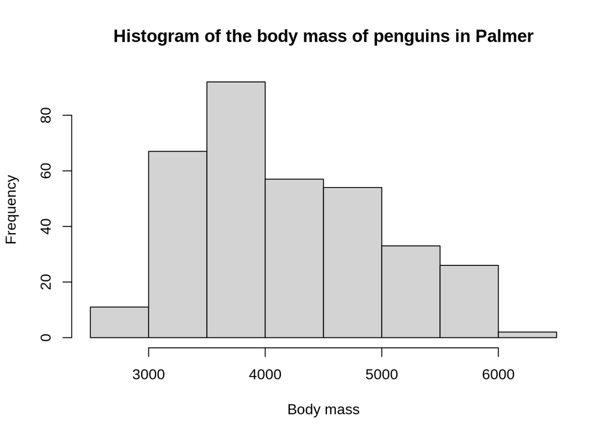

```r
# Producing a histogram
hist(
  Penguins$body_mass,
  main = "Histogram of the body mass of penguins in Palmer",
  xlab = "Body mass"
  )
```

# (c)

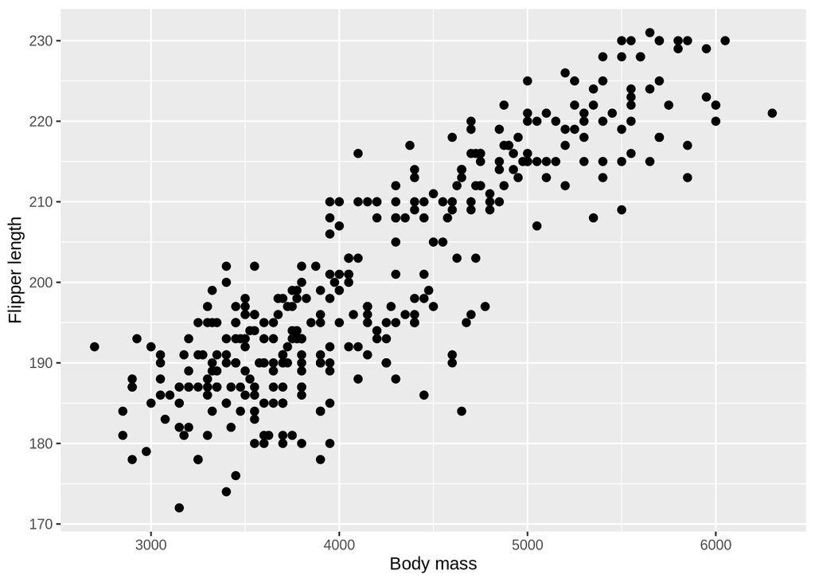

```r
# Creating a scatter plot
ggplot2::ggplot(Penguins, mapping = aes(x = body_mass, y = flipper_len)) +
  geom_point(size = 2) +
  labs(
    x = "Body mass",
    y = "Flipper length"
    )
```

- There is a strong linear relationship between body mass and flipper length

# (d)

```r
# Computing the correlation between body mass and flipper length (excluding the missing observations)
cor(Penguins$body_mass, Penguins$flipper_len, use = "pairwise.complete.obs") # pairwise deletion to maximise data usage
```

```
## [1] 0.8712018
```

- A correlation of 0.8712018 shows a very strong positive correlation between body mass and flipper length

# (e)

```r
# Fitting a simple linear regression model with body mass as the response variable and flipper length as the predictor variable

bm_fl_model <- lm(body_mass ~ flipper_len, data = Penguins)

summary(bm_fl_model) # Viewing the results of the linear model
```

```
##
## Call:
## lm(formula = body_mass ~ flipper_len, data = Penguins)
##
## Residuals:
##      Min       1Q   Median       3Q      Max
## -1058.80  -259.27   -26.88   247.33  1288.69
##
## Coefficients:
##              Estimate Std. Error t value Pr(>|t|)
## (Intercept) -5780.831    305.815  -18.90   <2e-16 ***
## flipper_len    49.686      1.518   32.72   <2e-16 ***
## ---
## Signif. codes:  0 '***' 0.001 '**' 0.01 '*' 0.05 '.' 0.1 ' ' 1
##
## Residual standard error: 394.3 on 340 degrees of freedom
##   (2 observations deleted due to missingness)
## Multiple R-squared:  0.759,  Adjusted R-squared:  0.7583
## F-statistic:  1071 on 1 and 340 DF,  p-value: < 2.2e-16
```

## (i)

$$\hat{y} = -5780.831 + 49.686x$$

## (ii)

- The coefficient implies that for every addition unit of flipper length, body mass increases by 49.686

## (iii)

- The coefficient of determination = 0.759
  - or (75.9%)

# (f)

```r
# Fitting a multiple linear regression with body mass as the response variable, while flipper length and bill length are the predictor variables

penguins_model <- lm(body_mass ~ flipper_len + bill_len, data = Penguins)
summary(penguins_model) # Viewing the results of the linear model
```

```
##
## Call:
## lm(formula = body_mass ~ flipper_len + bill_len, data = Penguins)
##
## Residuals:
##     Min      1Q  Median      3Q     Max
## -1090.5  -285.7   -32.1   244.2  1287.5
##
## Coefficients:
##              Estimate Std. Error t value Pr(>|t|)
## (Intercept) -5736.897    307.959 -18.629   <2e-16 ***
## flipper_len    48.145      2.011  23.939   <2e-16 ***
## bill_len        6.047      5.180   1.168    0.244
## ---
## Signif. codes:  0 '***' 0.001 '**' 0.01 '*' 0.05 '.' 0.1 ' ' 1
##
## Residual standard error: 394.1 on 339 degrees of freedom
##   (2 observations deleted due to missingness)
## Multiple R-squared:   0.76,  Adjusted R-squared:  0.7585
## F-statistic: 536.6 on 2 and 339 DF,  p-value: < 2.2e-16
```

## (i)

$$\hat{y} = -5736.897 + 48.145x_1 +
6.047x_2$$

## (ii)

- The R-squared value of the model in part (e) is nearly identical to that of the model in part (f)
  - part (e)’s R-squared = 0.759, which could be rounded to 0.76 resulting in the same R-squared as part (f)

## (iii)

- I don’t think the multiple linear regression model improves prediction given that the adjusted R-squared barely changed between the two models.